# Data_ReAnalysis_Assignment

Nandini Sharma

November 5, 2016

# Overview

This assignment replicates some of the descriptive and inferential statistical analysis done by the authors of the paper:

*Determinants of Immigrant Apprehensions: The Case of U.S. Immigration* *Bilol Buzurukov and Byeong Wan Lee*

# Abstract

THe authors explore the cross country variations of immigrant apprehensions in the United States. In particular they study and analyse the effects of their home country’s situation with respect to education, income, social ills like corruption, theft, homicide, etc., on their apprehension ratio in the United States. For e.g. their data suggests:

*Every one-point increase in Mexico’s corruption level produces 18 additional apprehensions per 100,000 Mexican immigrants*

*The ratio is multiplied by 100,000 to keep the dependent variable of the regression model in its log form to reduce the skewness of the distribution while mitigating the potential problem of heteroscedasticity*

The data set that authors have shared already has the APR calculated for various countries, along with their respective quantified values for explanatory variables like corruption, education etc. The authors quantify corruption index by:

*‘Corruption Control’ data are selected (e.g., Kaufmann et al., 2014) for their broader country coverage and data completeness with no missing values after the year 2000.5 The index is scaled from –2.5 to 2.5 with –2.5 representing the highest level of corruption (weakest control) and 2.5, the lowest level of corruption (strongest control). The data are multiplied by –1 for a more intuitive interpretation of the scale such that the higher the value, the higher the level of corruption.*

You can refer to the paper to know more about the authors quantifies indices for other explanatory variables.

Another important explanatory variable to be considered is:

*Regional and Income Group Dummies: Immigrants’ attitudes toward compliance with local laws and regulations are assumed to reflect varying characteristics that exist across regions and income groups that their country of origin belongs to. In this regard, the full country sample is divided into five regions and four income groups, and two sets of dummy variables are used to verify the existence of cross-county variations in alien apprehensions attributable to regional and income group differences. Regional dummies correspond to Americas, Africa, Asia, Europe, and the Middle East, and income group dummies correspond to high-, low-, lower-middle-, and upper-middle-income countries.*

# ReAnalysis

As mentioned earlier, the data set that authors have shared already has the APR calculated for various countries, along with their respective quantified values for explanatory variables like corruption, education etc.

In this assignment I have replicated the descriptive statistical analysis i.e. the mean, standard deviation, and range calculation for the explanatory variables with respect to all the countries in question.

# Descriptive statistics

## Reading Data

```r
# Reading the official data with outliers from github
Offdata<-read.table("https://raw.githubusercontent.com/nandsh/data-reanalysis-assignment/master/3.104-CountrySample.tab", header=TRUE)
# Brief up of what the data looks like
head(Offdata)
```

```
##       Country       APR Corruption  Homicide     Theft Alcohol    Income
## 1 Afghanistan 122.46224  1.5045581 4.6833333 2.0833333    38.3   90.0000
## 2     Albania 403.72591  0.6769467 5.0583333 0.2916667    27.5  726.8012
## 3   Argentina 237.48758  0.4545665 6.0083333 0.9416667    33.1 1838.0825
## 4     Armenia 171.74389  0.5938233 2.3583333 0.2833333    17.9  859.1850
## 5   Australia  82.21454 -1.9861069 1.3000000 0.0000000    31.3 5680.2244
## 6     Austria  27.32391 -1.8336962 0.6833333 0.0000000    29.6 3965.2460
##   Unemployment  Tourism   Investment Education Traffic Distance
## 1     7.500000      500 3.750000e+00  3.335833    19.8 11931.99
## 2    13.500000  1726583 9.166667e-01  9.784167    12.7  9146.36
## 3    10.150000  4409833 1.231167e+04  9.260833    12.6  9017.25
## 4    23.400000   515750 1.666667e+00 10.561667    18.1 10546.20
## 5     5.241667  5580833 8.904467e+04 11.355833     6.1 15183.75
## 6     4.483333 21317000 1.187317e+04  9.313333     6.6  8343.54
##   Prostitution HighIncome LowIncome LowerMiddleIncome UpperMiddleIncome
## 1            0          0         1                 0                 0
## 2            0          0         0                 0                 1
## 3            1          0         0                 0                 1
## 4            1          0         0                 1                 0
## 5            1          1         0                 0                 0
## 6            1          1         0                 0                 0
##   Africa Americas Asia Europe MiddleEast
## 1      0        0    1      0          0
## 2      0        0    0      1          0
## 3      0        1    0      0          0
## 4      0        0    1      0          0
## 5      0        0    1      0          0
## 6      0        0    0      1          0
```

```r
attach(Offdata)
```

## My Analyses

```r
ObservationVar<-colnames(Offdata) # Creating a vector of all the explanatory variables e.g. corruption
ObservationVar<-ObservationVar[-1] #Removing the first entry which corresponds to country
#Initializing variables for holding mean, standard deviation , range and count of observations
MeanObs<-NULL
SDObs<-NULL
MinObs<-NULL
MaxObs<-NULL
CountObs<-NULL
#Using the variables in the vector observationsVar to calculate their respective means, sd,and ranges.
for (i in 1:length(ObservationVar)) {
  #Parsing the string as a variable name in the data set and calculating the corresponding statistics i.e.   passing "Corruption" from vectory ObservationsVar as a variable Offdata$Corruption to function mean()

  MeanObs<-c(MeanObs,round(mean(eval(parse(text = ObservationVar[i]))),2))
  SDObs<-c(SDObs,round(sd(eval(parse(text = ObservationVar[i]))),2))
  MinObs<-c(MinObs,round(min(eval(parse(text = ObservationVar[i]))),2))
  MaxObs<-c(MaxObs,round(max(eval(parse(text = ObservationVar[i]))),2))
  CountObs<-c(CountObs,length(eval(parse(text = ObservationVar[i]))))
}
DS<-data.frame(variable=ObservationVar, Observations=CountObs, Mean=MeanObs, SD=SDObs, Minimum=MinObs, Maximum=MaxObs)
DS
```

```
##             variable Observations       Mean          SD Minimum
## 1                APR          104     435.82     1108.24   17.80
## 2         Corruption          104      -0.02        1.04   -2.45
## 3           Homicide          104       8.98       12.46    0.40
## 4              Theft          104       0.60        0.74    0.00
## 5            Alcohol          104      32.24       13.59    2.90
## 6             Income          104    2065.55     2209.79   35.00
## 7       Unemployment          104       8.41        5.31    0.87
## 8            Tourism          104 6943575.14 12158045.84  500.00
## 9         Investment          104   23153.48    66192.55   -4.92
## 10         Education          104       8.23        2.59    1.86
## 11           Traffic          104      15.77        8.92    3.00
## 12          Distance          104    8864.74     3640.50 1632.45
## 13      Prostitution          104       0.47        0.50    0.00
## 14        HighIncome          104       0.33        0.47    0.00
```

[output cut: 31 more lines]

## Author’s Analysis

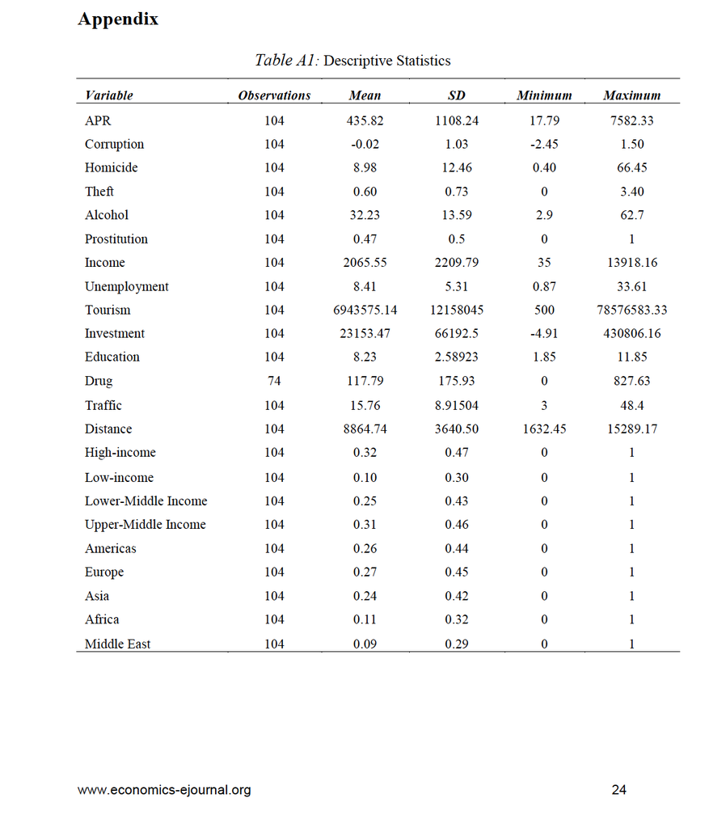